# Assignment2

JingLiu_18231917

13 February 2019

```r
library(ggplot2)
library(dplyr)
library(scales)
library(tidyverse)
dataset<-read.csv("airqualityv2.csv")
```

1.filling data the missing data in conlumn Ozone, I pick the average value of Ozone per month to filling the NA data, because filling NA value by average could reduce the influence of those NA value, which won’t change the average acutal values.for the coding, I use for loop to raplce each empty value by average value.

```r
ave_Ozone<-select(dataset,Ozone,Month)%>%group_by(Month)%>%summarise(ave=as.integer(mean(Ozone,na.rm = TRUE)))
for(i in 1:length(dataset$Ozone)){
  if(is.na(dataset$Ozone[i])){
    if(dataset$Month[i]==5){
      dataset$Ozone[i]=ave_Ozone$ave[1]
    }else if(dataset$Month[i]==6){
      dataset$Ozone[i]=ave_Ozone$ave[2]
    }else if(dataset$Month[i]==7){
      dataset$Ozone[i]=ave_Ozone$ave[3]
    }
  }
}
print(dataset)
```

```
##    Ozone Wind Temp Month Day
## 1     41  7.4   67     5   1
## 2     36  8.0   72     5   2
## 3     12 12.6   74     5   3
## 4     18 11.5   62     5   4
## 5     23 14.3   56     5   5
## 6     28 14.9   66     5   6
## 7     23  8.6   65     5   7
## 8     19 13.8   59     5   8
## 9      8 20.1   61     5   9
## 10    23  8.6   69     5  10
## 11     7  6.9   74     5  11
## 12    16  9.7   69     5  12
## 13    11  9.2   66     5  13
## 14    14 10.9   68     5  14
```

[output cut: 78 more lines]

2.grouping bar I decided using Month as x axis and type as filling colour, beacuse we can see each month the comparision ofOzone, Wind, and Temp, here we can get a conclusion is that each mouth the ave_Temp is largest and the ave_Wind is smallest, then for each group we can see that the ave_Temp and the ave_Ozone are increasing during 3 month while ave_Wind is descresing.

```r
library(tidyr)
value_ave<-group_by(dataset,Month)%>%summarise(ave_Ozone=mean(Ozone),ave_Wind=mean(Wind),ave_Temp=mean(Temp))
tidy_value_ave<-gather(value_ave,key=type,value=outcome,ave_Ozone:ave_Wind:ave_Temp)
```

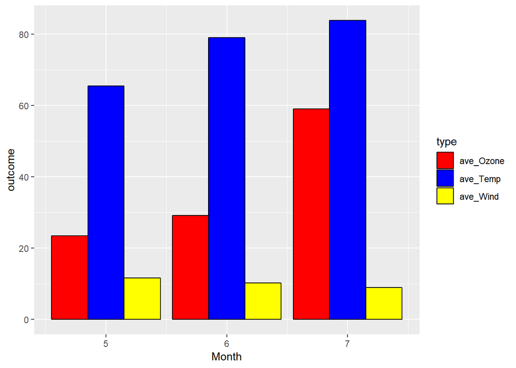

```r
ggplot(tidy_value_ave, aes(x=Month, y = outcome, fill=type)) +
  geom_col(position="dodge", colour = "black") +
  scale_fill_manual(values = c("red", "blue","yellow"))
```

3.Ordering group Ordering group is is using reorder function to merger two atttribute, first is a unique id of each month and type, another attribute is the value of average values.From this graph we can see the aver_Tep is much more greater than others for each mouth.

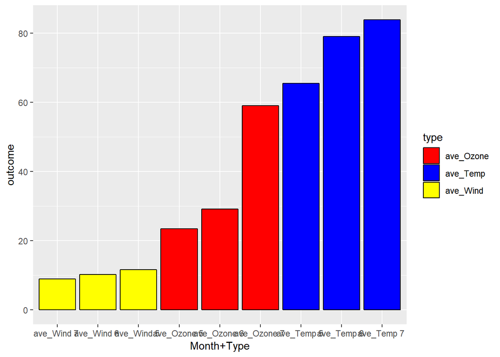

```r
tidy_value_ave2<-mutate(tidy_value_ave,Id=paste(as.character(type),as.character(Month),seq=""))
ggplot(tidy_value_ave2, aes(x=reorder(Id,outcome), y = outcome, fill=type))+
  geom_col(colour = "black") +
  scale_fill_manual(values = c("red", "blue","yellow")) +
  xlab("Month+Type")
```

4.Diverging bars this is about diversging bars, it used the left join function to combine the average values of each type and main table, then caculate the gap of each value and average value, from the graph we can clearly see that the actual value is greater or lower than the actual value because of different color and direction.

```r
dataset2<-left_join(dataset,value_ave,key="Month")
```